# Homework_08

Grace Durant

3/16/2022

# **Creating Fake Data Sets to Explore Hypotheses**

### Random data set simulating whale and boat presence/absence

```r
vec0 <- c(50,15)
vec1 <- c(100, 85)
dataMatrix <- rbind(vec0,vec1)
rownames(dataMatrix) <- c("WhaleAbsence", "WhalePresence")
colnames(dataMatrix) <- c("BoatAbsence", "BoatPresence")
str(dataMatrix)
```

```
##  num [1:2, 1:2] 50 100 15 85
##  - attr(*, "dimnames")=List of 2
##   ..$ : chr [1:2] "WhaleAbsence" "WhalePresence"
##   ..$ : chr [1:2] "BoatAbsence" "BoatPresence"
```

- non-random numbers were used because when random numbers were generated, they did not look similar to the original data collected. It was suggested that specific numbers be used and a matrix created from those numbers, instead of random generation.

### Code to analyze the data

- the independent variable was boats (x)
- the dependent variable was whales (y)
- a chi-squared test was used to analyze the data because both variables were categorical

```r
print(chisq.test(dataMatrix))
```

```
##
##  Pearson's Chi-squared test with Yates' continuity correction
##
## data:  dataMatrix
## X-squared = 9.5504, df = 1, p-value = 0.001999
```

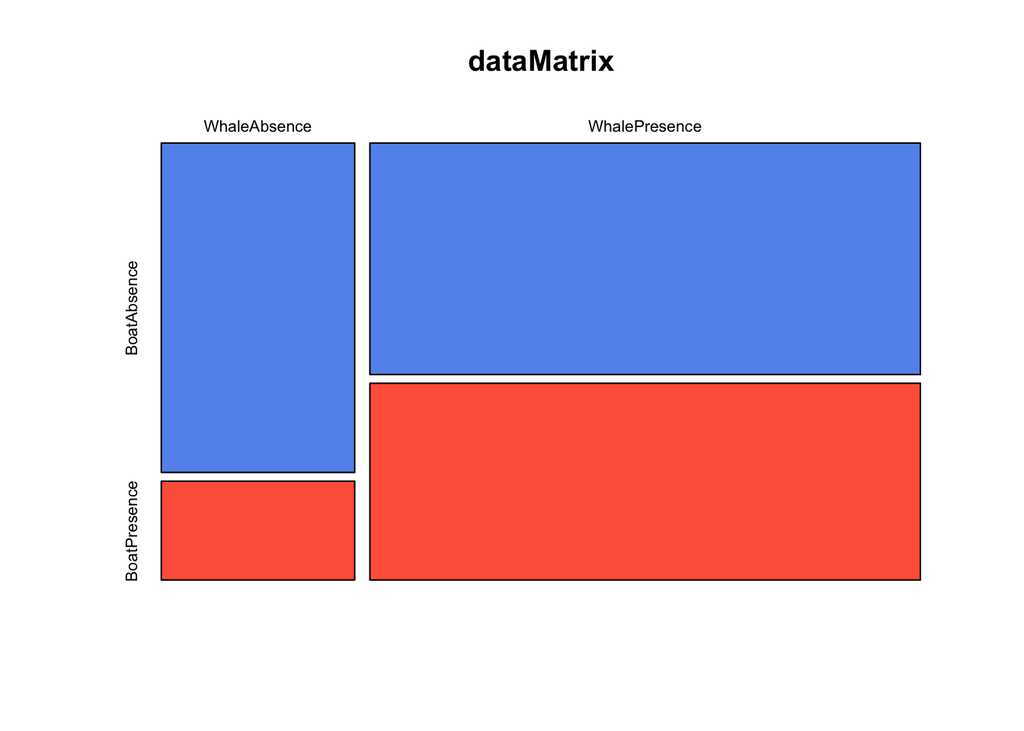

```r
mosaicplot(x=dataMatrix,
           col=c("cornflowerblue","tomato","black"),
           shade=FALSE)
```

- When the values of the table were whale + boat absence = 50, only whale absence = 150, only whale presence = 700, and both presence= 100, the p-value was < 2.2e-16
- to check how small the differences between groups could be to still detect a significant pattern, I manually changed the values for each category.
- The smallest difference obtained while maintaining a significant p-value was whale + boat absence = 210, only whale absence = 190, only whale presence = 355, and both presence= 245, the p-value was 0.04357. When the overall size of the two “groups” (whales vs boats) was very different, differences within those groups did not significantly change the p-value. However, the more different each of the 4 categories values was, the more significant the data become and the lower the p-value.
- When the overall sample size changed and the sample size was decreased 10 fold, small changes made significant differences. This was not the case with a larger sample size. However, small sample sizes needed significant differences between the categories to generate a small p-value. A sample size of 250 was the lowest sample size tried that yielded significant results. However, at this sample size, the categroies within the matrix had to be very different values.